# Fatores que influenciam o consumo

Diogo Alexandre Alonso de Freitas, Nº104841

Eliane Susso Efraim Gabriel, Nº103303

João Francisco Marques Gonçalves da Silva Botas, Nº104782

Maria João Ferreira Lourenço, Nº104716

Pedro Brígido Machado, Nº98601

Umeima Adam Mahomed, Nº99239

31-03-2022

## Sumário Executivo

O presente documento traduz a análise de uma base de dados retirada de um questionário denominado 𝘗𝘦𝘳𝘧𝘪𝘭 𝘥𝘦 𝘊𝘰𝘯𝘴𝘶𝘮𝘰 𝘦 𝘊𝘰𝘮𝘱𝘰𝘳𝘵𝘢𝘮𝘦𝘯𝘵𝘰 𝘥𝘦 𝘊𝘰𝘮𝘱𝘳𝘢. Neste documento são abordadas questões relacionadas com os fatores que influenciam a tomada de decisão dos jovens no momento da compra, sendo que os mesmos conduziram o estudo em causa. Para realizar esta pesquisa foram utilizadas diversas plataformas como o R, o Jamovi e o Excel.

## Introdução

O objetivo da exploração da base de dados foi perceber qual a relevância de um leque de fatores na tomada de decisão da compra de diferentes produtos por parte dos jovens, pelo que fomos investigar se o preço, a imagem do produto, a localização da loja e outros fatores influenciavam a forma de consumo dos jovens. Com este propósito partimos para a investigação das variáveis que poderiam estar relacionadas com o nosso objetivo, estudando-as a nível individual e a nível relacional.

## Perfil dos Jovens

Antes de começarmos a analisar as variáveis é necessário conhecer o perfil dos inquiridos e, para isso, iremos analisar alguns dados sobre os mesmos.

A amostra é composta por 1575 indivíduos portugueses e espanhóis dos 18 aos 25 anos. No gráfico 1 é possivel verificar a existência de um maior número de inquiridos com 21 anos.

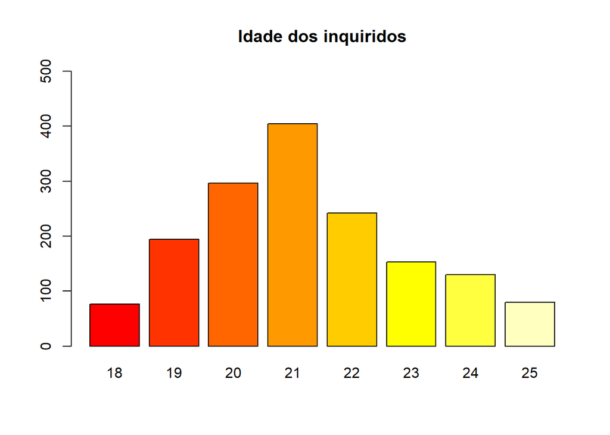

*Gráfico 1 - Gráfico de barras sobre a idade dos inquiridos*

Ao observar a tabela 1 percebemos que a média das idades é 21.2. Ao examinar o desvio padrão é possível verificar que este tem o valor de 1.8, um valor razoável, o que demonstra que a média é um valor fidedigno e com pouca discrepância com os valores reais(isto acontece, pois existe cada vez menos inquiridos quanto mais se afastam da idade mediana que é 21). Além disso, 25% dos jovens têm entre 18 e 20 anos e 75% dos mesmos têm entre 18 e 22 anos.

| Medidas_idade | Valor_idade |
| --- | --- |
| N | 1,575.0 |
| Média | 21.2 |
| Mediana | 21.0 |
| Desvio padrão | 1.8 |
| Variância | 3.2 |
| Mínimo | 18.0 |
| Máximo | 25.0 |
| 1ºQuartil | 20.0 |
| 3ºQuartil | 22.0 |
| Assimetria | 0.3 |
| Curtose | 2.5 |

*Tabela 1 - Tabela com medidas descritivas sobre a idade dos inquiridos*

Podemos observar no gráfico 2 que a assimetria é positiva, visto que a curva de densidade está a aumentar até ao valor da média. Assimetria positiva que corresponde ao valor da moda ser menor que o da mediana, e menor que o da média.(Moda ≤ Mediana < Média)

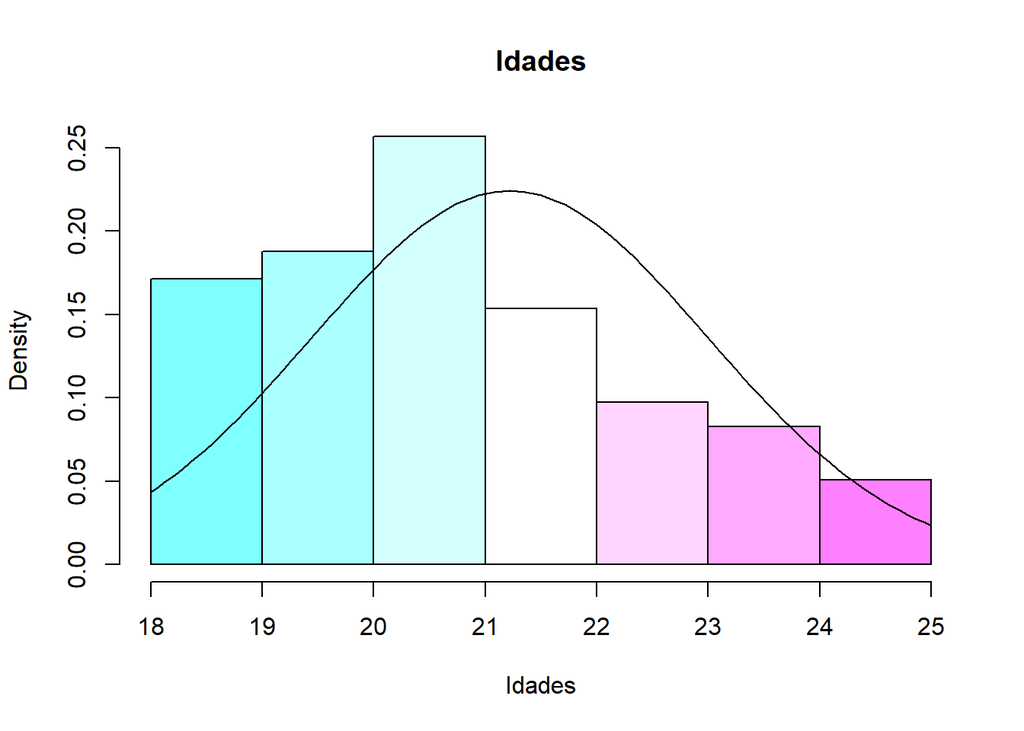

*Gráfico 2 - Histograma sobre a idade dos inquiridos*

Além disso, a amostra é constuída por 989 mulheres (62.8%) (Tabela 2) e o país com mais representantes é Portugal com 955 participantes (60.6%) (Tabela 3).

| Sexo_inquiridos | n | Percentagem |
| --- | --- | --- |
| Feminino | 989 | 62.8 |
| Masculino | 586 | 37.2 |

*Tabela 2 - Tabela de frequência sobre o sexo dos inquiridos*

| País_origem_inquiridos | n | Percentagem |
| --- | --- | --- |
| Espanha | 620 | 39.4 |
| Portugal | 955 | 60.6 |

*Tabela 3 - Tabela de frequência sobre o país de origem dos inquiridos*

O gráfico 3 demonstra que, tanto em Espanha, como em Portugal, existiram mais participantes do sexo feminino do que do sexo masculino.

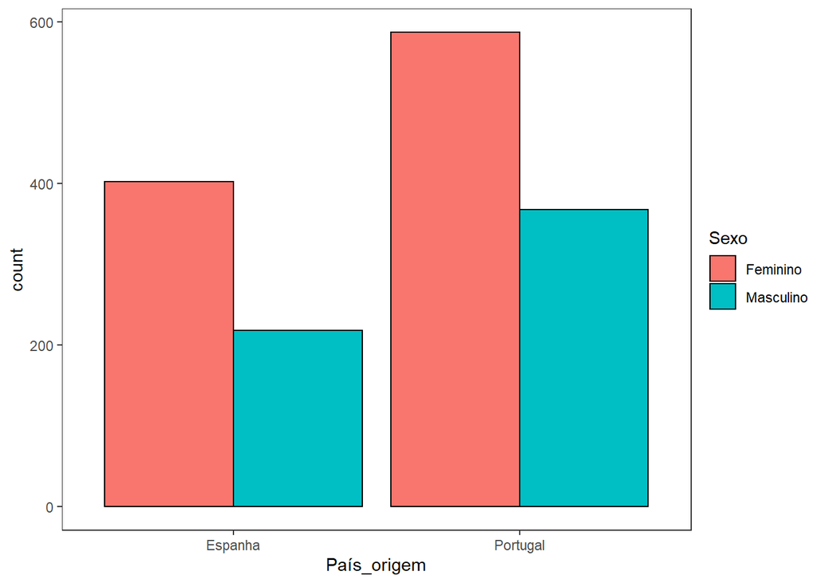

*Gráfico 3 - Gráfico de barras com o sexo e o país de origem dos inquiridos*

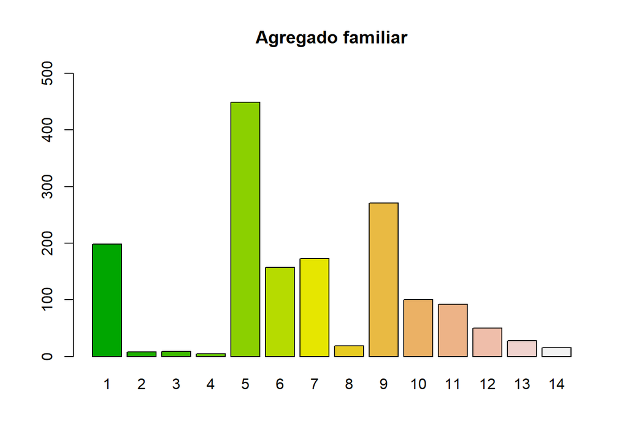

*Gráfico 4 - Gráfico de barras com o agregado familiar*

Para termos uma melhor perspetiva acerca dos agregados criámos a tabela 4 com vários dados descritivos sobre o agregado dos inquiridos. Ao analisarmos a tabela 4 percebemos que 75% dos jovens vivem com 9 ou menos pessoas. Em média, os jovens vivem com 6.6 pessoas, mas analisando o desvio padrão, podemos verificar que este não é muito pequeno, atigindo o valor de 3.2, demonstrando que esta média pode ser um pouco longe da realidade. Para reforçar esta ideia, temos o valor da variância que é muito elevado, demonstrando que os valores dos agregados estão muito dispersos da média.

| Medidas | Valor |
| --- | --- |
| N | 1,575.0 |
| Média | 6.6 |
| Moda | 5.0 |
| Mediana | 6.0 |
| Desvio padrão | 3.2 |
| Variância | 10.0 |
| Mínimo | 1.0 |
| Máximo | 14.0 |
| 1ºQuartil | 5.0 |
| 3ºQuartil | 9.0 |
| Assimetria | -0.1 |
| Curtose | 2.5 |

*Tabela 4 - Tabela de medidas descritivas sobre o agregado familiar*

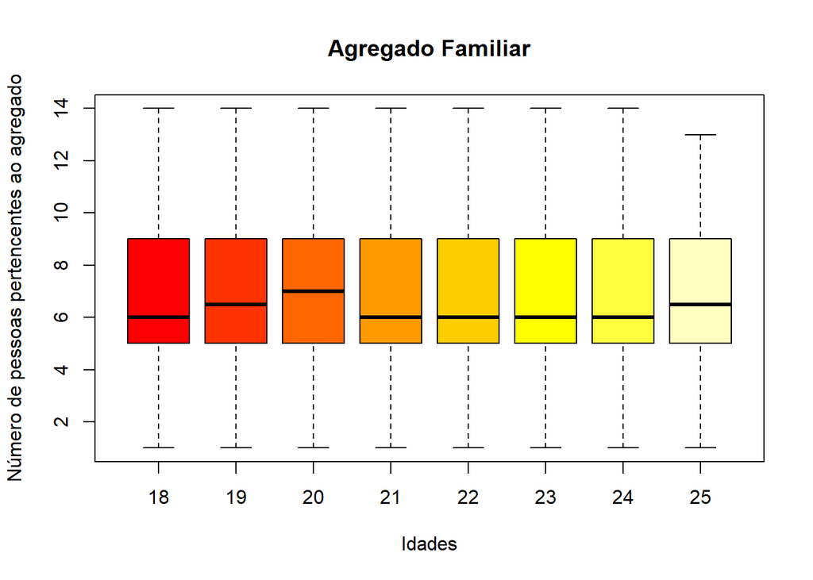

*Gráfico 5 - Boxplot com a relação entre idades e o número de pessoas pertencentes ao agregado*

## Fidelidade a lojas

Seguidamente, colocámos a pergunta: Será que a fidelidade a lojas nos jovens da amostra é muito notória? Fomos investigá-la construindo a tabela 5. Ao analisarmos os dados da tabela 5 conseguimos notar que apenas 1515 jovens responderam a esta pergunta. A posição e a identificação dos 60 jovens que não o fizeram encontra-se a seguir.

```
##
##  DESCRIPTIVES
##
##  Descriptives
##  ------------------------------
##                          N
##  ------------------------------
##    Fidelidade.a.lojas    1515
##  ------------------------------
##
##
##  FREQUENCIES
##
##  Frequencies of Fidelidade.a.lojas
##  --------------------------------------------------
##    Levels    Counts    % of Total    Cumulative %
##  --------------------------------------------------
##    Não          573      37.82178        37.82178
##    Sim          942      62.17822       100.00000
##  --------------------------------------------------
```

*Tabela 5 - Tabela de frequência sobre a fidelidade a lojas*

```
##  [1]   10   76  100  102  106  134  160  186  198  212  218  251  279  286  320
## [16]  340  361  367  439  443  503  526  527  542  554  609  610  668  687  710
## [31]  799  865  889  891  895  923  949  975  987 1001 1007 1040 1068 1075 1109
## [46] 1129 1150 1156 1228 1232 1292 1315 1316 1331 1343 1398 1399 1457 1476 1499
```

```
## TRUE
##   60
```

De seguida, foi construído o gráfico 6 para possibilitar o estudo desta variável nos 2 países. Ao analisá-lo é possivel verificar que os inquiridos espanhóis têm uma maior tendência para serem fiéis à loja onde compram do que os portugueses.

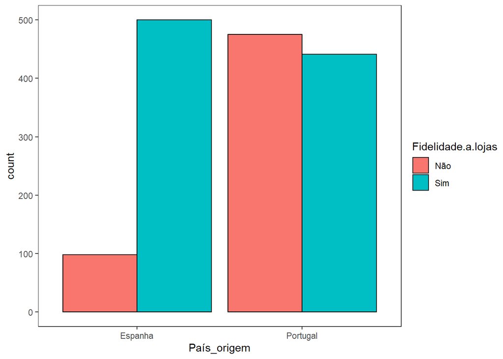

*Gráfico 6 - Gráfico de barras sobre a fidelidade a lojas em função do país*

Posteriormente, decidimos realizar o gráfico 7 que relaciona a fidelidade a lojas com o sexo. Ao consultá-lo é possivel verificar que o sexo feminino tem uma maior tendência para ser fiel às lojas do que o sexo masculino.

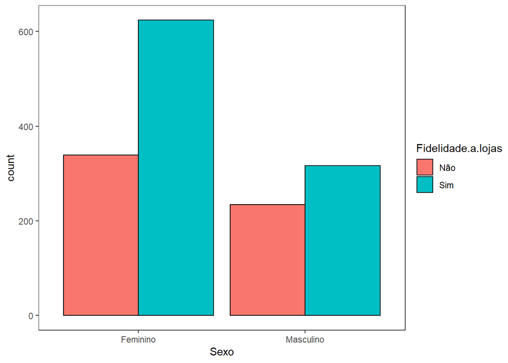

*Gráfico 7 - Gráfico de barras sobre a fidelidade a lojas em função do sexo*

## Conveniência da localização da loja

Para a exploração da variável “Conveniência da localização da loja” realizou-se o gráfico 8 com o objetivo de perceber se a nossa amostra considerava esta variável importante na hora da compra. Ao analisá-lo percebemos que 77,8% dos inquiridos julgam que a localização da mesma é pouco importante ou importante, o que nos leva a crer que os jovens não têm este parâmetro em grande consideração na hora da compra. Deste modo, podemos concluir que a localização da loja é pouco relevante aquando da tomada de decisão da compra.

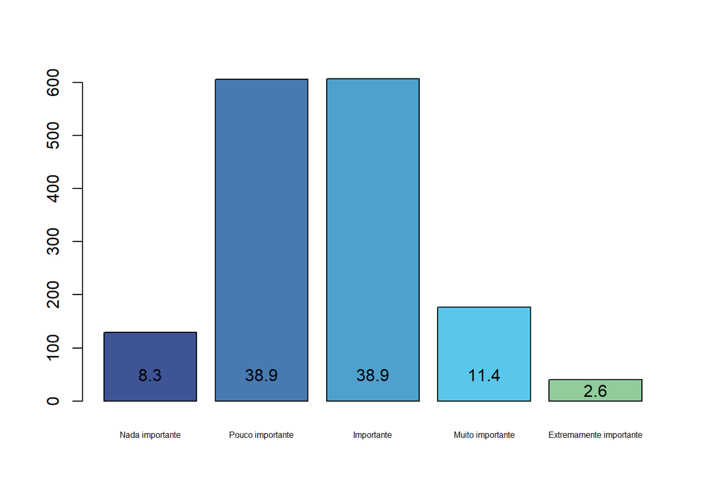

*Gráfico 8 - Gráfico de barras sobre a conveniência da localização da loja (com valores em percentagem)*

## Preço

Seguidamente colocámos a seguinte tese: será que a nossa amostra de jovens considera o preço importante aquando do ato de tomada de decisão da compra. Primeiramente, fomos verificar os valores omissos da variável “Preço”. Nas células com valores omissos procedeu-se à imputação de valores, utilizando a mediana do preço, pois são apenas 8 valores, pelo que não irão descaracterizar a amostra.

```
##    Mode   FALSE    TRUE
## logical    1567       8
```

```
##    Mode   FALSE
## logical    1575
```

Ao analisarmos a tabela 6 vemos que a maioria da amostra situa-se na categoria “Importante”(42.2%) e que apenas 0.6% consideram o preço nada importante.

| Preço | n | Percentagem |
| --- | --- | --- |
| Nada importante | 10 | 0.6 |
| Pouco importante | 64 | 4.1 |
| Importante | 665 | 42.2 |
| Muito importante | 604 | 38.3 |
| Extremamente importante | 232 | 14.7 |

*Tabela 6 - Tabela de frequência sobre o preço*

## A qualidade do produto

Procedemos à verificação da seguinte hipótese: Será que a amostra de jovens dá um peso significativo à qualidade do produto quando vai comprá-lo? Para esse efeito construímos a tabela 7. Ao observarmos a tabela 7 correspondente à escala de Likert para as opiniões dos jovens acerca da importância da qualidade do produto, concluímos que, apenas 1.7% da amostra total a consideram nada ou pouco importante o que nos leva a concluir que a qualidade do produto é realmente relevante aquando da compra do mesmo.

| Qualidade_do_produto | n | Percentagem |
| --- | --- | --- |
| Nada importante | 4 | 0.3 |
| Pouco importante | 22 | 1.4 |
| Importante | 329 | 21.0 |
| Muito importante | 782 | 49.9 |
| Extremamente importante | 430 | 27.4 |

*Tabela 7 - Tabela de frequência sobre a qualidade do produto*

De seguida, fomos verificar como o sexo e os países de origem se relacionavam com esta variável e, para tal, criámos um boxplot (Gráfico 9). Através deste é possível verificar que os dois países de origem têm pontos de vista um pouco diferentes, apesar de possuírem a mesma mediana (4 - “Muito Importante”). Enquanto os inquiridos espanhóis referem esta variável como estando principalmente entre as categorias 2 e 5, uma vez que poucos inquiridos deram 1 a esta variável; os inquiridos portugueses avaliaram substancialmente esta variável entre 3 e 5, sendo que existem poucos casos que a avaliaram com 2. Dando assim a entender que os portugueses consideram esta variável mais importante que os espanhóis. Em relação ao sexo, não houve diferenças.

```
##
##  DESCRIPTIVES
```

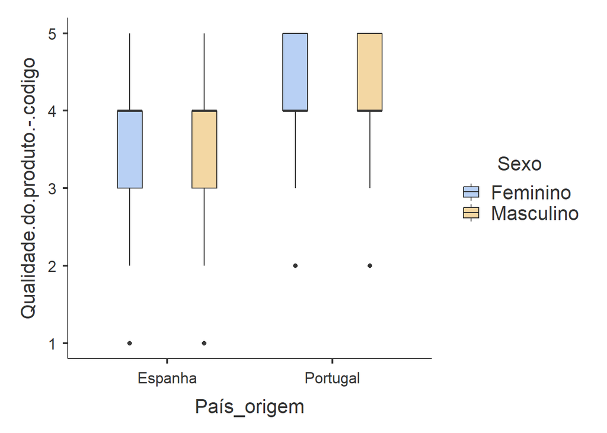

*Gráfico 9 - BoxPlot com a relação entre o País de origem e o sexo com a qualidade do produto*

## A imagem do produto

Realizámos o gráfico 10 para estudar a importância da imagem do produto para os jovens inquiridos.

Podemos observar no gráfico 10 que para 46.2% dos inquiridos a imagem do produto é importante e que para apenas 4.6% é nada ou extremamente importante. Pelo que esta variável não é tão relevante quando comparada com a qualidade do produto.

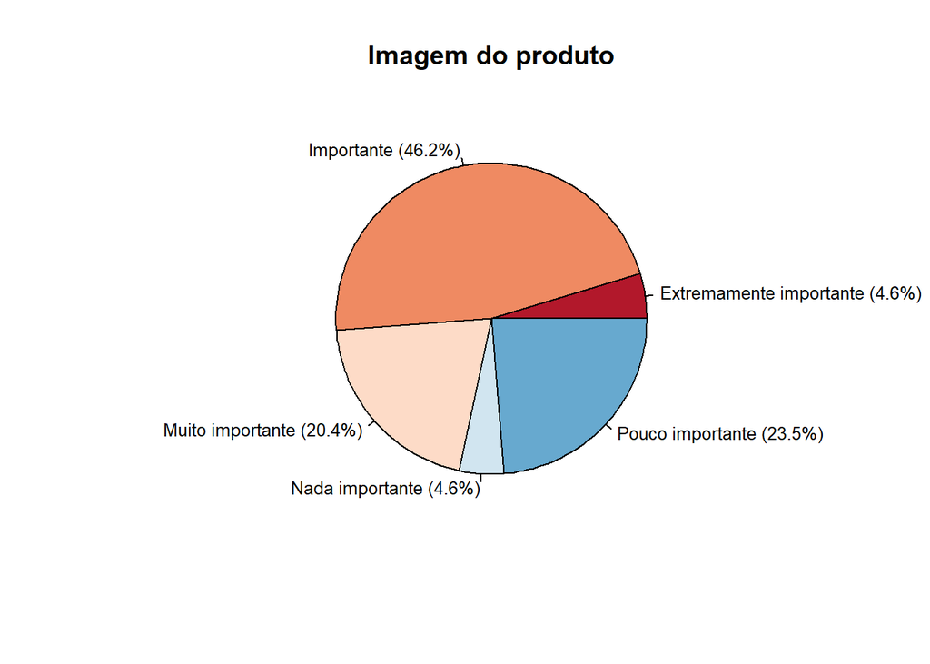

*Gráfico 10 - Gráfico circular sobre a imagem do produto*

## A necessidade do produto

Por fim, fomos estudar a última variável relacionada com a necessidade do produto para verificar se esta seria um fator a ter em conta ao comprar um produto.

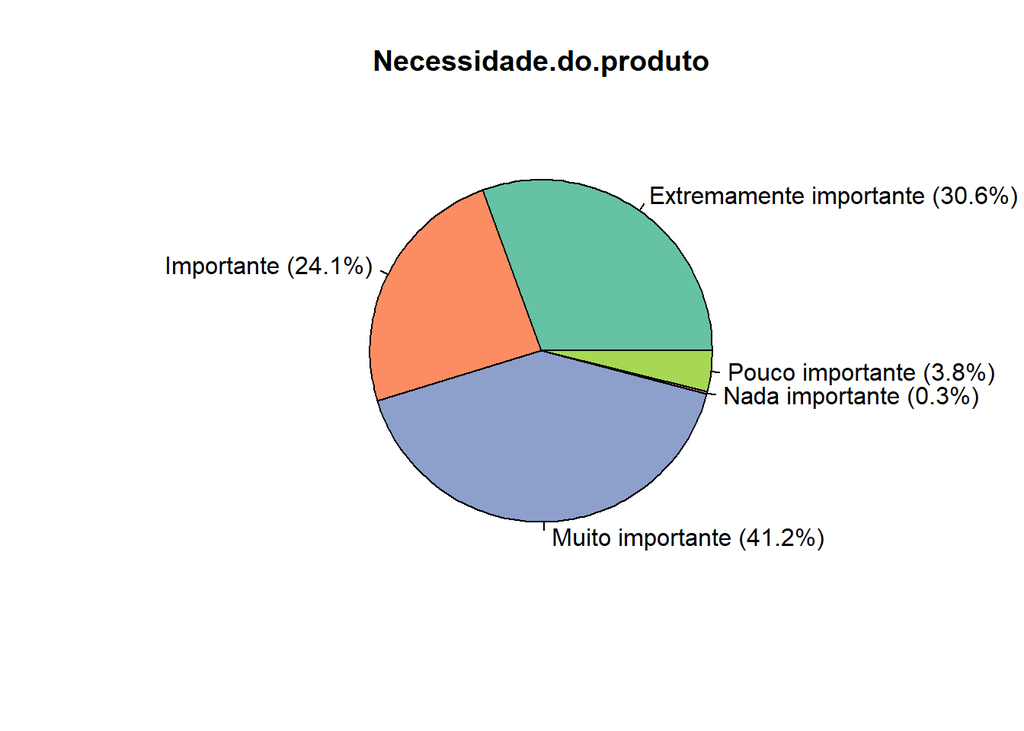

*Gráfico 11 - Gráfico circular sobre a necessidade do produto*

Criámos um boxplot com o objetivo de estudar o comportamento dos inquiridos, segundo o seu país de origem e o sexo com a necessidade do produto. Visionando o gráfico 12 é possível verificar que, em relação ao sexo, existem algumas diferenças. Apesar de ambos possuírem a mesma mediana, no sexo masculino a maioria avaliou esta variável com 4 e 5, alguns com 3, existindo ainda algumas exceções nos dois países e alguns homens portugueses a avaliar esta variável com 2; em Espanha ocorreu o mesmo e ainda houve respostas avaliadas com 1. Em relação ao sexo feminino, existiu uma concordância entre os dois países, havendo um maior número de avaliações entre 3 e 5 e uma menor quantidade de respostas em 2. Para finalizar, em relação ao país, as avaliações foram quase iguais, porém em Portugal ninguém avaliou com 1, como podemos ver nos outliers.

```
##
##  DESCRIPTIVES
```

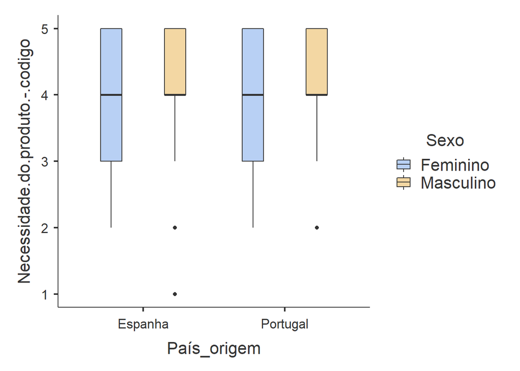

*Gráfico 12 - BoxPlot com a relação entre o País de origem e o sexo com a necessidade do produto*

## Conclusão

Ao estudar as respostas do inquérito feito aos jovens portugueses e espanhóis foi possível aferir que a maioria dos jovens eram portugueses, do sexo feminino e rondavam os 21 anos.

Além disso, foi possível concluir que o agregado familiar não tem muita influência nas respostas dadas, o que não vai de encontro às nossas expectativas, dado que pressupusemos que este fator fosse influenciar a importância dada ao preço, quantidade e necessidade do produto aquando da compra.

Em relação à fidelidade a lojas, conseguimos perceber que os espanhóis dão mais importância a este fator do que os portugueses. Também é de salientar que o público feminino tem este fator mais em conta que o masculino.

Quanto à conveniência da localização da loja e à imagem do produto, pode-se aferir que não são muito relevantes na decisão de compra. Já a qualidade, a necessidade e o preço do produto são variáveis que se revelaram muito importantes, uma vez que a média e a mediana destas variáveis foram as mais altas.

Esta conclusão vai de encontro com as nossas expectativas, uma vez que antes de realizarmos este estudo tínhamos como pressuposto que o preço e a qualidade seriam as variáveis mais relevantes na hora da compra, no entanto, observámos que a necessidade do produto também é semelhantemente relevante.

De seguida temos a seguinte tabela que ilustra o resultado obtido:

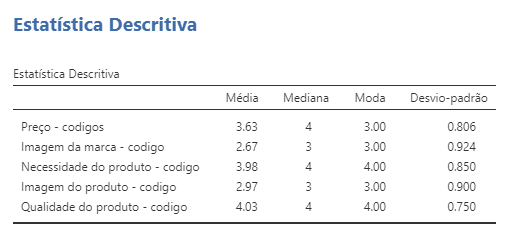

*Tabela 8 - Tabela com as medidas descritivas de algumas variáveis*